# Illustration of credible set using Matthew’s “proxy SNP” idea

Peter Carbonetto

October 19, 2017

## Outline

The aim of this analysis is to try out a simple fine-mapping idea. We can also build on this analysis to test out other ideas for fine-mapping (that is, estimating credible sets for the location of the causal variant near an identified assocation).

## Set up environment

Load a few packages.

```r
library(ggplot2)
library(cowplot)
library(varbvs)
```

Also, install the varbvs package from the “finemap” branch on Github.

```r
library(devtools)
install_github("pcarbo/varbvs",ref = "finemap",subdir = "varbvs-R")
```

## Script parameters

This vector specifies the (additive) phenotypic effects of the SNPs. In this case, exactly 2 SNPs (about 3 Mb apart on chromosome 11) affect the quantitative trait.

```r
beta            <- rep(0,531)
beta[c(88,506)] <- c(0.2,-0.35)
```

The causal variant should be within the credible set with this probability.

```r
credint.prob <- 0.95
```

For identifying the credible set, compute proxy probabilities for all SNPs in LD with the target SNP based on this threshold.

```r
ld.threshold <- 0.2
```

## Load genotype data

Load the genotype data for the 531 SNPs at the bone-mineral density locus on chromosome 11 that was identified in the *Nature Genetics* manuscript.

These are data from outbred (CFW) mice, so will not have the same LD patterns as humans. I’m using mouse instead of human data because we don’t have to worry about about making the mouse data publicly available.

```r
load("../datafiles/cfw.chr11bmd.RData")
n <- nrow(X)
p <- ncol(X)
```

Center the columns of X so that each column has a mean of zero.

```r
rep.row <- function (x, n)
  matrix(x,n,length(x),byrow = TRUE)
X <- X - rep.row(colMeans(X),n)
```

## Simulate phenotype data

Set the random number generator seed.

```r
set.seed(1)
```

Generate the quantitative trait measurements.

```r
y <- c(X %*% beta + rnorm(n))
```

## Fit variational approximation to posterior

Fit the fully-factorized variational approximation to the posterior distribution of the coefficients for a linear regression model of a continuous outcome (quantitiative trait), with spike and slab priors on the coefficients.

```r
fit <- varbvs(X,NULL,y,sa = 1,verbose = FALSE)
```

## Compute proxy probabilities

Compute the correlations between all the SNPs.

```r
R <- cor(X)
```

To test the idea of computing credible SNP sets based on “proxy probabilities”, here I choose the top 2 SNPs by posterior inclusion probability (PIP), take all candidate SNPs in LD with these top 2 SNPs (based on a pre-specified threshold), then compute the Bayes factors measuring the improvement in “fit” by using the candidate SNPs instead of each of the top SNPs.

First, do this for the top SNP.

```r
top.markers <- summary(fit)$top.vars$index
i     <- top.markers[1]
vars1 <- which(R[,i]^2 >= ld.threshold)
BF1   <- varbvsproxybf(X,NULL,y,fit,i,vars1)
```

Note that the Bayes factors are computed separately for each hyperparameter setting. Here, to simplify the example, we will just use the Bayes factors from the first hyperparameter setting (corresponding to the smallest prior inclusion probability).

Also note that the implementation of `varbvsproxybf` is currently very inefficient and probably will be too slow for examples with thousands of SNPs.

Next, do the same for the SNP with the second-highest PIP.

```r
top.markers <- summary(fit)$top.vars$index
j     <- top.markers[2]
vars2 <- which(R[,j]^2 >= ld.threshold)
BF2   <- varbvsproxybf(X,NULL,y,fit,j,vars2)
```

This function computes the “probability probabilities” assuming that exactly 1 SNP is causal, then selects the smallest set of SNPs such that the sum of the proxy probabilities is greater than “pr”.

```r
get.credible.set <- function (bf, pr) {
  pp      <- bf/sum(bf)
  markers <- order(bf,decreasing = TRUE)
  n       <- min(which(cumsum(pp[markers]) > credint.prob))
  return(markers[1:n])
}
```

Get the credible SNP sets for the top 2 SNPs (using the first hyperparameter setting only).

```r
cred1 <- vars1[get.credible.set(BF1[,1],credint.prob)]
cred2 <- vars2[get.credible.set(BF2[,1],credint.prob)]
print(c(length(cred1),length(cred2)))
# [1]  72 191
```

## Plot fine-mapping results

Plot the PIPs of the SNPs, marking the two credible SNP sets with crosses, and colouring the points according to LD with the top 2 SNPs.

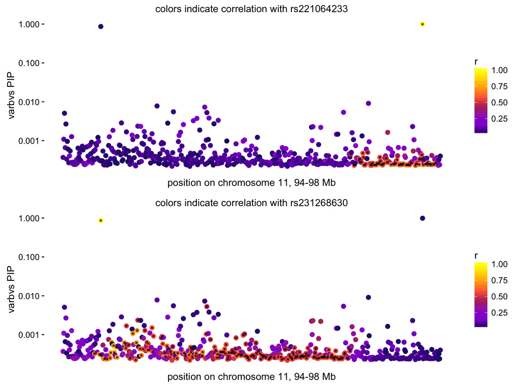

```r
create.finemap.plot <- function (pip, r, markers, plot.title = NULL) {
  clrs <- c("midnightblue","darkviolet","darkorchid","maroon",
            "tomato","orange","gold","yellow")
  dat <- data.frame(pos = 1:p,pip = fit$pip,r = r)
  return(ggplot(mapping = aes(x = pos,y = pip,color = r),
                environment = environment()) +
    geom_point(data = dat,size = 2,shape = 19) +
    geom_point(data = dat[markers,],color = "black",shape = 4,size = 0.5) +
    scale_x_continuous(breaks = NULL) +
    scale_y_continuous(trans = "log10",breaks = 10^(-4:0)) +
    scale_color_gradientn(colors = clrs) +
    labs(x = "position on chromosome 11, 94-98 Mb",y = "varbvs PIP",
         title = plot.title) +
    theme_cowplot(font_size = 11) +
    theme(axis.line  = element_blank(),
          plot.title = element_text(size = 11,face = "plain")))
}
regionplot1 <-
  create.finemap.plot(fit$pip,abs(R[,i]),cred1,
                      paste("colors indicate correlation with",map[i,"id"]))
regionplot2 <-
  create.finemap.plot(fit$pip,abs(R[,j]),cred2,
                      paste("colors indicate correlation with",map[j,"id"]))
plot_grid(regionplot1,regionplot2,nrow = 2)
```